# 140.651 - Lab 6

### Midterm notes

TAs grading respective problems:

- Marta Karas (mkaras2@jhmi.edu): Problems 1,2
- Nathan Dyjack (ndyjack1@jhmi.edu): Problems 3,4
- Jingning Zhang (jzhan218@jhu.edu): Problem 5

### HW3 Problem 5

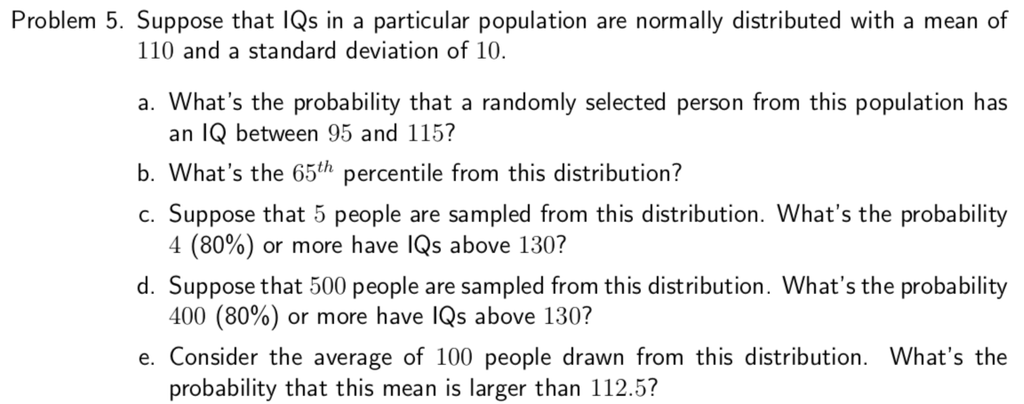

#### (a) What is the probability that a randomly selected person from this population has an IQ between $95$ and $115$?

Then
$$P(95 \leq X \leq 115) = F_X(115) - F_X(95).$$

We can get it from `R` directly using `pnorm`. Notes:

- Function `pnorm(q, mean = 0, sd = 1, lower.tail = TRUE)` gives the cumulative distribution function (CDF) of $N(\mu = 0,\sigma = 1)$ distribution.
- Function `pnorm(q, mean = 100, sd = 10, lower.tail = TRUE)` gives the cumulative distribution function (CDF) of $N(\mu = 100, \sigma=10)$ distribution.
- Using `pnorm(q, lower.tail = TRUE)`, i.e. with default value `lower.tail = TRUE`, gives $P(q \leq 115) = F(115)$, whereas using `pnorm(q, lower.tail = FALSE)` gives $P(q > 115) = 1 - F(115)$.

To answer the problem:

```r
pnorm(q = 115, mean = 110, sd = 10) - pnorm(q = 95, mean = 110, sd = 10)
```

```
## [1] 0.6246553
```

#### (b) What is the $65$-th percentile from this distribution?

- `qnorm(p, mean = 0, sd = 1, lower.tail = TRUE)` gives the quantile function $Q(p)$, that is, it returns the value $x$ such that
  $$F_X(x) = P(X \leq x) = p.$$

```r
qnorm(p = 0.65, mean = 110, sd = 10)
```

```
## [1] 113.8532
```

#### (c) Suppose that $5$ people are sampled from this distribution. What is the probability $4$ ($80\%$) or more have IQs above $130$?

- For one individual, $P(IQ > 130)$ is

```r
# P(IQ > 130) = 1 - P(IQ <= 130) =  1 - F(130)
p.IQ = 1 - pnorm(q = 130, mean = 110, sd = 10)
p.IQ
```

```
## [1] 0.02275013
```

- The probability of seeing $4$ or more out of $5$ with $IQ > 130$ can be described with Binomial distribution with parameters $n=5$ and $p=0.02275013$.
  - Recall: $Binom(n,p)$ is a discrete probability distribution of the number of successes in a sequence of $n$ independent experiments.
  - Here: denote $Y$ – result of experiment of sampling $n=5$ people, success – sampling a person with IQs above $130$, probability o success – $p=0.02275013$.

```r
# P(Y = 4) + P(Y = 5)
dbinom(x = 4, size = 5, prob = p.IQ) + dbinom(x = 5, size = 5, prob = p.IQ)
```

```
## [1] 1.315009e-06
```

```r
# Equivalently:
# P(Y >= 4) = 1 - P(Y <= 3) = 1 - F(3)
1 - pbinom(q = 3, size = 5, prob = p.IQ)
```

```
## [1] 1.315009e-06
```

#### (d) Suppose that $500$ people are sampled from this distribution. What is the probability $400 (80\%)$ or more have IQs above $130$?

Now $Y \sim Binom(n = 500, p = 0.02275013)$.

```r
# P(Y >= 400) = 1 - P(Y < 399)
1 - pbinom(q = 399, size = 500, prob = p.IQ)
```

```
## [1] 0
```

#### (e) Consider the average of $100$ people drawn from this distribution. What is the probability that this mean is larger than $112.5$?

We use the Central Limit Theorem (CLT; lecture 8).

- Consider $X_i$, $i=1,\ldots,n$ - a collection of iid (Independent and identically distributed) random variables with mean $\mu$ and variance $\sigma^2$. Denote their sample average as $\overline{X}_n$.
- From Central Limit Theorem we have
  $$P \left( \frac { \overline { X } _ { n } - \mu } { \sigma / \sqrt { n } } \leq z \right) \rightarrow \Phi ( z ),$$
  that is, the normalized quantity
  $$\frac { \overline { X } _ { n } - \mu } { \sigma / \sqrt { n } } = \frac { \text { Estimate } - \text { Mean of estimate } } { \text { Std. Err. of estimate } }$$
  converges in distribution to standard normal random variable.
- Using the above, and with certain abuse of notation, we sometimes write
  $$\overline { X } _ { n } \rightarrow N \left( \mu , \frac { \sigma ^ { 2 } } { n } \right)$$
- Then

$$P \left( \overline { X }_n > 112.5 \right) = 1 - P \left( \overline { X }_n \leq 112.5 \right) \\
= 1 - P \left( \frac { \overline { X }_n - 110 } { 10 / \sqrt { 100 } } \leq \frac { 112.5 - 110 } { 10 / \sqrt { 100 } } \right) = 1 - P \left( Z \leq \frac { 112.5 - 110 } { 10 / \sqrt { 100 } } \right) = 1 - \Phi ( 2.5 )$$

for $Z \sim N(0,1)$.

```r
1 - pnorm(q = 2.5, mean = 0, sd = 1)
```

```
## [1] 0.006209665
```

### HW3 Problem 4

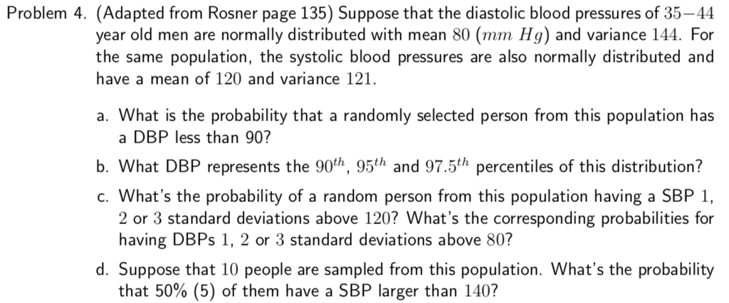

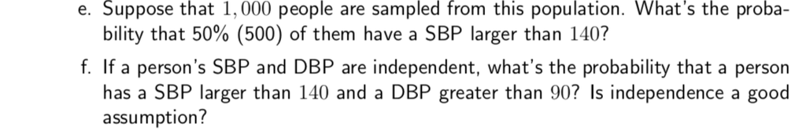

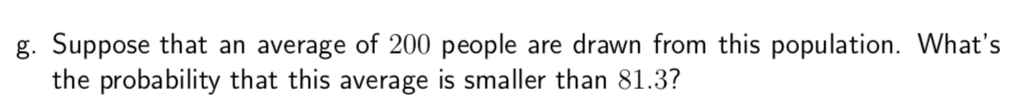

#### (a) What is the probability that a randomly selected person from this population has a DBP (diastolic blood pressure) less than $90$?

```r
# P(DBP <= 90)
pnorm(q = 90, mean = 80, sd = sqrt(144))
```

```
## [1] 0.7976716
```

#### (b) What DBP represents the $90$-th, $95$-th and $97.5$-th percentiles of this distribution?

Again, `qnorm(p, mean = 0, sd = 1)` gives the quantile function $Q(p)$, that is, it returns the value $x$ such that
$$F_X(x) = P(X \leq x) = p.$$

```r
q.vec = c(0.90, 0.95, 0.975)
percentiles.out = qnorm(p = q.vec, mean = 80, sd = 12)
names(percentiles.out) = q.vec
percentiles.out
```

```
##       0.9      0.95     0.975
##  95.37862  99.73824 103.51957
```

#### (c) What is the probability of a random person from this population having a SBP $1$, $2$ or $3$ standard deviations above $120$? What is the corresponding probabilities for having DBPs $1$, $2$ or $3$ standard deviations above $80$?

```r
## SBP variable mean and sd deviation
SBP.mean <- 120
SBP.sd <- 11
# P(SBP > SBP.mean + k * SBP.sd) = 1 - P(SBP <= SBP.mean + k * SBP.sd)
1 - pnorm(q = c(SBP.mean + 1 * SBP.sd,
                SBP.mean + 2 * SBP.sd,
                SBP.mean + 3 * SBP.sd),
          mean = SBP.mean,
          sd = SBP.sd)
```

```
## [1] 0.158655254 0.022750132 0.001349898
```

```r
## DBP variable
DBP.mean <- 80
DBP.sd <- 12
1 - pnorm(q = c(DBP.mean + 1 * DBP.sd,
                DBP.mean + 2 * DBP.sd,
                DBP.mean + 3 * DBP.sd),
          mean = DBP.mean,
          sd = DBP.sd)
```

```
## [1] 0.158655254 0.022750132 0.001349898
```

```r
## N(0,1)
X.mean <- 0
X.sd <- 1
1 - pnorm(q = c(X.mean + 1 * X.sd,
                X.mean + 2 * X.sd,
                X.mean + 3 * X.sd),
          mean = X.mean,
          sd = X.sd)
```

```
## [1] 0.158655254 0.022750132 0.001349898
```

- Note the rule works same for all normal distributions; you may hence use even $N(0,1)$ to compute probability of being 1, 2 or 3 standard deviations above the mean for both SBP and DBP

```r
## Define vector c(mean + k * standard_deviation) for N(0,1), for k=1,2,3
q.vec = c(0 + 1, 0 + 2, 0 + 3)
# 1 - P(X <= 0 + k * 1)
out <- 1 - pnorm(q = q.vec)
round(out, 4)
```

```
## [1] 0.1587 0.0228 0.0013
```

#### (d) Suppose that 10 people are sampled from this population. What is the probability that 50% (5) of them have a SBP larger than 140?

- For one subject, the probability is $P(SBP > 140)$

```r
p <- 1 - pnorm(q = 140, mean = 120, sd = 11)
```

- Then, the probability that exactly five of them have SBP larger than $140$ is

```r
dbinom(x = 5, size = 10, prob = p)
```

```
## [1] 1.036001e-05
```

#### (e) Suppose that 1,000 people are sampled from this population. What’s the probability that 50% (500) of them have a SBP larger than 140?

Similarly to above. We use the same variable `p` for $P(SBP > 140)$:

```r
dbinom(x = 500, size = 1000, prob = p)
```

```
## [1] 0
```

(Note that the probability is not **actually** 0, but is very close to 0).

#### (f) If a person’s SBP and DBP are independent, what’s the probability that a person has a SBP larger than 140 and a DBP greater than 90? Is independence a good assumption?

- Assuming independence of SBP and DBP,
  $$P(X_{SBP}>140, X_{DBP}>90) = P(X_{SBP}>140) \cdot P(X_{DBP}>90).$$

```r
(1 - pnorm(q = 90, mean = 80, sd = 12)) * (1- pnorm(q = 140, mean = 120, sd = 11))
```

```
## [1] 0.006984006
```

Independence is not a good assumption here. Why? …

#### (g) Suppose that an average of 200 people are drawn from this population. What’s the probability that this average is smaller than $81.3$?

(Similar as in 5e.)

For $X_i$ being $i-th$ person measurement of DBP, $i=1,\ldots,200$:
$$\begin{aligned}
X_i & \sim N(\mu = 80, \sigma^2 = 144) \\
\overline { X }_{200} & \sim N(\mu = 80, \sigma^2 = \frac{144}{200}) \\
& \sim N(\mu = 80, \sigma = \frac{12}{\sqrt{200}}) \\
\end{aligned}$$

$$P \left( \overline { X }_{200} < 81.3 \right) = P \left( \frac { \overline { X }_{200} - 80 } { 12 / \sqrt { 200 } } < \frac { 81.3 - 80 } { 12 / \sqrt { 200 } } \right)= P \left( Z < \frac { 81.3 - 80 } { 12 / \sqrt { 200 } } \right)= \Phi ( 1.532 )$$

for $Z \sim N(0,1)$.

```r
pnorm(1.532, mean = 0, sd = 1)
```

```
## [1] 0.9372388
```

### HW3 Problem 3

#### (a) What’s the probability of getting $5$ or more eggs imploding in this experiment if the true probability of implosion is $10\%$? Interpret this number.

- Denote $X$ - number of eggs imploding in this experiment.
- Assume $X \sim Binom(\text{size}=6, \text{pr}=p)$.

```r
## Pr(X = 5) + Pr(X = 6)
dbinom(x = 5, size = 6, prob = 0.1) + dbinom(x = 6, size = 6, prob = 0.1)
```

```
## [1] 5.5e-05
```

Equicalently, one may calculate $Pr(X \geq 5)$ using R. Recall:

- `pbinom(q, size, prob, lower.tail=TRUE)` returns $Pr(X \leq q)$
- `pbinom(q, size, prob, lower.tail=FALSE)` returns $Pr(X > q)$

Here we want $Pr(X \geq 5) = Pr(X > 4)$.

```r
## Pr(X > 4)
pbinom(q = 4, size = 6, prob = 0.1, lower.tail = FALSE)
```

```
## [1] 5.5e-05
```

- Probability of 5 or more eggs imploding is $0.000055$.

#### (b) What is the maximum likelihood estimate for the probability of implosion?

In problem 1a you will derive that likelihood estimate of parameter $p$ is
$$\hat{p} = \frac{x}{n}.$$

Hence $\hat{p} = \frac{5}{6}$.

#### (c) Plot and interpret the likelihood for the probability of implosion.

We use (from 1a)
$$L ( p , x ) = p ^ { x } ( 1 - p ) ^ { n - x }$$
and substitude what we learned from experiment: $x = 5$ (and we have $n = 6$).

We plot $L ( p , x )$ for different $p$:

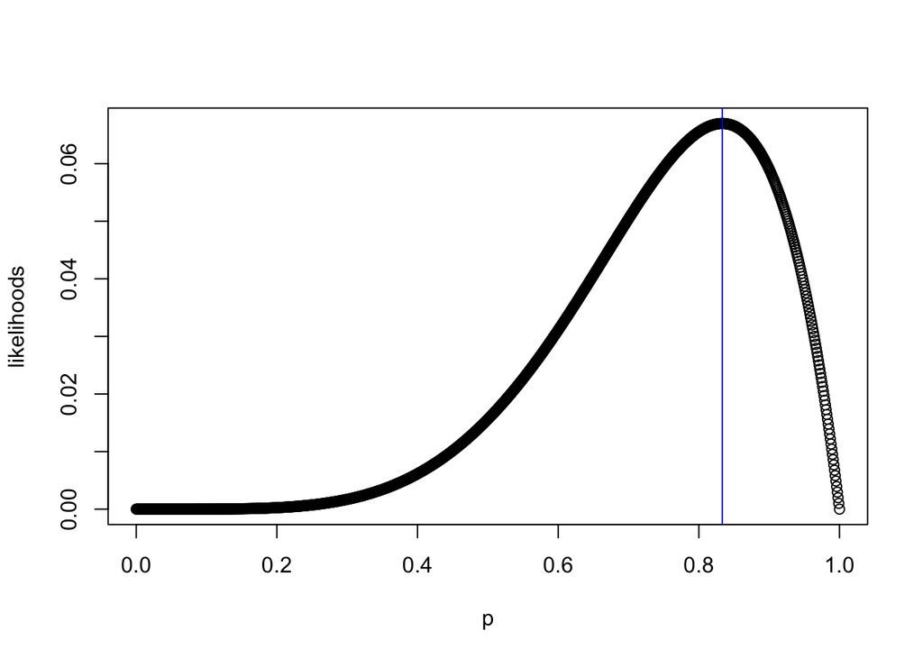

```r
p <- seq(0, 1, length.out = 1000)
likelihoods = p^5*(1-p)^1
plot(p, likelihoods)
abline(v = 5/6, col = "blue")
```

We can also standardize $L ( p , x )$ values so as the maximum of the plotted function is $1$:

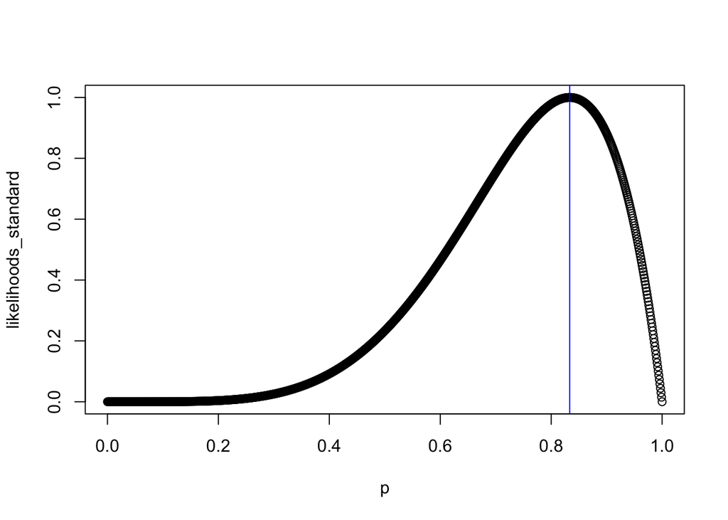

```r
likelihoods_standard <- likelihoods/max(likelihoods)
plot(p, likelihoods_standard)
abline(v = 5/6, col = "blue")
```

Example of interpretation:

```r
p[range(which(likelihoods_standard > 1/8))]
```

```
## [1] 0.4304304 0.9909910
```

- Values of $p$ from the range $(0.430, 0.991)$ are more than $1/8$ times supported by the data than the maximally supported value $\frac{5}{6}$ ($= 0.833$).